# Homework 6: Hypothesis Testing

#### Question 1

Make a table called `with_state` that includes one row for each school that's present in *both* `sfa` and `hd`. Each row should have the school's ID, its number of undergraduate students, its number of Pell grant recipients, and its state. (It's okay if it has other columns besides those four.) Use the same names for those columns as the corresponding columns in the original data tables.

```python
## join the two tables
with_state = sfa.join("Institution ID", hd).drop(3,4,5,7)
with_state
```

| Institution ID | Number of Pell grant recipients | Number of undergraduates | State (abbreviated) |
| --- | --- | --- | --- |
| 100654 | 2967 | 4170 | AL |
| 100663 | 3958 | 11291 | AL |
| 100690 | 225 | 329 | AL |
| 100706 | 1930 | 5882 | AL |
| 100724 | 4240 | 5130 | AL |
| 100751 | 5905 | 28026 | AL |
| 100760 | 1316 | 2020 | AL |
| 100812 | 1402 | 3414 | AL |
| 100830 | 1698 | 4239 | AL |
| 100858 | 3403 | 20175 | AL |

... (7146 rows omitted)

#### Question 2

Make a table called `students_and_grants_by_state` that has the total number of undergraduates and Pell grant recipients in each *state*. Use the same names for those columns as the corresponding columns in the original data tables.

```python
students_and_grants_by_state = with_state.group("State (abbreviated)", np.sum).drop(1)
students_and_grants_by_state
```

| State (abbreviated) | Number of Pell grant recipients sum | Number of undergraduates sum |
| --- | --- | --- |
| AK | 8318 | 31522 |
| AL | 118944 | 269650 |
| AR | 75434 | 164062 |
| AS | 914 | 1795 |
| AZ | 304393 | 648368 |
| CA | 893974 | 2500929 |
| CO | 124044 | 321048 |
| CT | 65908 | 185443 |
| DC | 15025 | 49786 |
| DE | 16392 | 51521 |

... (49 rows omitted)

#### Question 3

Create a table called `pell_proportions` with two columns: "State (abbreviated)" is the name of each state, and "Pell proportion" is the proportion of students in each state who receive Pell grants.

```python
pell_proportions = Table().with_columns("State (abbreviated)", students_and_grants_by_state["State (abbreviated)"],
                                       "Pell proportion", students_and_grants_by_state["Number of Pell grant recipients sum"]/students_and_grants_by_state["Number of undergraduates sum"])
pell_proportions
```

| State (abbreviated) | Pell proportion |
| --- | --- |
| AK | 0.263879 |
| AL | 0.441105 |
| AR | 0.45979 |
| AS | 0.509192 |
| AZ | 0.469476 |
| CA | 0.357457 |
| CO | 0.386372 |
| CT | 0.355408 |
| DC | 0.301792 |
| DE | 0.318162 |

... (49 rows omitted)

#### Question 4

Make a histogram of Pell grant proportions.

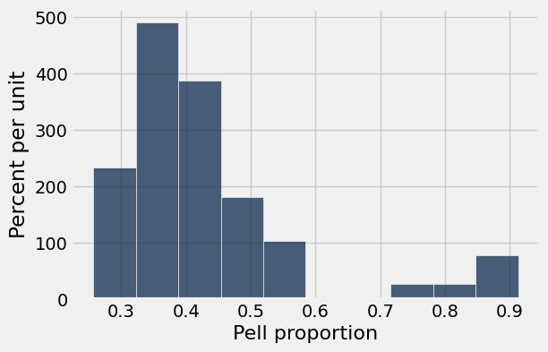

```python
pell_proportions.hist("Pell proportion")
```

The file `us.json` contains data about the boundaries of each US state. We have loaded it as a map by calling `Map.read_geojson`.

*Note:* The data come from [NOAA](http://www.nws.noaa.gov/geodata/catalog/national/html/us_state.htm).

The Map method `color` colors regions in a map according to numbers you specify. It takes 2 arguments:

1. A table whose first column names each region, and whose second column gives the intensity of the color you want for that region.
2. The named argument `key_on=...`, where the argument itself is a string that tells `color` how you're identifying each region. In this case, both `pell_proportions` and the map know about each state's abbreviation, so use `key_on="feature.properties.STATE"`. (This part looks a little bit magical, which is just a flaw in the design of the `datascience` library. If it confuses you, don't worry too much.)

#### Question 5

Create a map of the US, with each state colored according to the proportion of undergraduates in that state who are Pell grant recipients, with higher-proportion states getting higher-intensity colors.

```python
us_map = Map.read_geojson('/srv/data/DS_113_S23/HW/HW_6/us.json')
us_map.color(pell_proportions, key_on="feature.properties.STATE")
```

Make this Notebook Trusted to load map: File -> Trust Notebook

[interactive chart not shown]

#### Question 6

Describe any pattern you see in the data. Be sure to mention any parts of the data that *don't* fit the pattern you describe.

Usually Southern West states have higher proportion of undergraduates in that state who are Pell grant recipients. Among the states, Mississippi, Georgia, and Florida have the highest proportion than the others and the states closer to them have higher porportion than the farther states. However, Oregon, Montana, and Idaho have higher proportion even when they are far away from Mississippi, Georgia, and Florida.

## 3. Testing Dice

Students in a Data Science class want to figure out whether a six-sided die is fair or not. On a fair die, each face of the die appears with chance 1/6 on each roll, regardless of the results of other rolls. Otherwise, a die is called unfair. We can describe a die by the probability of landing on each face. For example, this table describes a die that is unfairly weighted toward 1:

```python
Table().with_columns(
    "Face", np.arange(1,7),
    "Probability", make_array(.5,.1,.1,.1,.1,.1)
)
```

| Face | Probability |
| --- | --- |
| 1 | 0.5 |
| 2 | 0.1 |
| 3 | 0.1 |
| 4 | 0.1 |
| 5 | 0.1 |
| 6 | 0.1 |

For this exercise, you can use the function `proportion_from_distribution` defined in lecture and the textbook. It is like .sample() or np.random.choice except that the items do not have the same chance of being selected. You must define the probabilities for different elements.

#### Question 1

Define a null hypothesis and an alternative hypothesis for this question.

**Null hypothesis:** The probability for each face of the die to appear is 1/6. p1=p2=p3=p4=p5=p6

**Alternative hypothesis:** Each face of the die appears with different chances on each roll, which is an unfair die.

We decide to test the die by rolling it 5 times. The proportions of the 6 faces in these 5 rolls are stored in a table with 6 rows. For example, here is the table we'd make if the die rolls ended up being 1, 2, 3, 3, and 5:

```python
Table().with_columns(
    "Face", np.arange(1,7),
    "Proportion", make_array(.2,.2,.4,0,.2,0)
)
```

| Face | Proportion |
| --- | --- |
| 1 | 0.2 |
| 2 | 0.2 |
| 3 | 0.4 |
| 4 | 0 |
| 5 | 0.2 |
| 6 | 0 |

The function `test_statistic`, defined below, takes a single table like this as its argument and returns a number (which we will use as a test statistic).

```python
def test_statistic(sample):
    avg_roll = sum(sample.column("Proportion") * sample.column("Face"))
    avg_for_fair_die = np.mean(np.arange(1, 6+1, 1))
    return abs(avg_roll - avg_for_fair_die)
```

#### Question 2

Describe in English what the test statistic is.

Test statistic describes how far the observed data is from the null hypothesis. Small values of this statistic favor the null hypothesis, and large values favor the alternative.

The code below takes five rolls from a fair die and then uses them as observations to conduct a simulation hypothesis test where the null hypothesis is that the rolls came from a fair die (which they did). When you run the code, it tells you the conclusion for the hypothesis test: true (the die is believed to be fair) or false (the die is believed to be unfair).

Please read the code and do your best to figure out how it works.

```python
# The probability distribution table for a fair die:
fair_die = Table().with_columns(
        "Face", np.arange(1, 6+1),
        "Probability", [1/6, 1/6, 1/6, 1/6, 1/6, 1/6])

def simulate_observations_and_test(actual_die):
    """Simulates die rolls from actual_die and tests the hypothesis that the die is fair.

    Returns True if that hypothesis is accepted, and False otherwise."""
    sample_size = 5
    p_value_cutoff = .2
    num_simulations = 250

    observation_set = proportions_from_distribution(actual_die, "Probability", sample_size)
    actual_statistic = test_statistic(observation_set.relabeled("Random Sample", "Proportion"))

    simulated_statistics = make_array()
    for _ in np.arange(num_simulations):
        one_observation_set_under_null = proportions_from_distribution(fair_die, "Probability", sample_size)
        simulated_statistic = test_statistic(one_observation_set_under_null.relabeled("Random Sample", "Proportion"))
        simulated_statistics = np.append(simulated_statistics, simulated_statistic)
    p_value = np.count_nonzero(actual_statistic < simulated_statistics) / num_simulations

    return p_value >= p_value_cutoff

# Calling the function to simulate a test of a fair die:
simulate_observations_and_test(fair_die)
```

```
True
```

#### Question 3

Since the function takes its observation from a fair die, how is it possible that it would then reject the null hypothesis that the rolls came from a fair die? What would this mean?

Although the chances for each faces of the die to appear are the same, since the observation is based on randomness, it is possible to reject the null hypothesis that the rolls came from a fair die.

#### Question 4

By examining the variable settings at the beginning of the function `simulate_observations_and_test`, compute the probability that it returns `False` when it is run on `fair_die`. You can call the function a few times to see what it does, but **don't** perform a simulation to compute this probability. Use your knowledge of hypothesis tests.

```python
probability_of_false = 0.2
```

#### Question 5

From the perspective of someone who wants to know the truth about the die, is it good or bad for the function to return `False` when its argument is `fair_die`?

The probabiloty to return False when the argument is fair_die is 20%, which is a lot for a fair die to have. From the perspective of a person who wants to know the truth about the die, it would be good for the function to return False, because if then, the person would know the fair_die is not always have the same chance to get each faces of the die.

#### Question 6

Verify your answer to question 4 by simulation, computing an approximate probability that `simulation_observations_and_test` returns `False`.

**Note:** This will be a little slow. 300 repetitions of the simulation should suffice to get an answer that's roughly correct and should require a minute or so of computation.

```python
num_test_simulations = 300
sampled_stats = make_array()

for i in np.arange(num_test_simulations):
    die_simulation = simulate_observations_and_test(fair_die)
    sampled_stats = np.append(sampled_stats, die_simulation)

approximate_probability_of_false = 1-(np.count_nonzero(sampled_stats)/300)
approximate_probability_of_false
```

```
0.20666666666666667
```